# Gases y combustión

### 1. Combustión

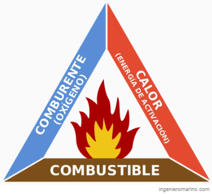

La **combustión** es una reacción química entre un combustible y un comburente (generalmente el oxígeno del aire) que libera energía en forma de calor y, muchas veces, luz.

Para que ocurra una combustión se necesitan tres elementos:

- Combustible.
- Oxígeno (comburente).
- Energía de activación (calor, chispa, llama, etc.).

Estos tres elementos forman el llamado **triángulo del fuego**.

### 2. Productos de la combustión

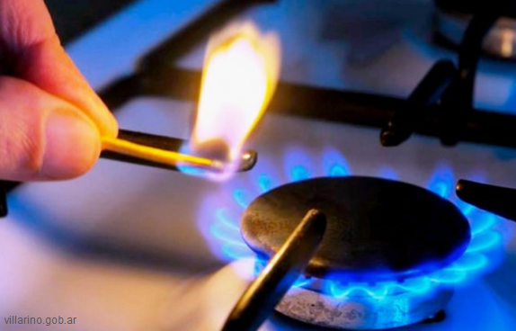

En una combustión ideal la reacción es:

`Oxigeno + Combustible → Agua + Dióxido de carbono`

**La llama**

Es la región donde la reacción está ocurriendo, con reactivos, productos y compuestos intermedios mezclados, todos a alta temperatura.

- **Una llama azul:** indica una combustión bastante completa;
- **Una llama amarilla o anaranjada:** contiene pequeñas partículas de carbono (hollín) incandescentes que brillan como si fueran diminutas brasas.
- Algunos elementos químicos pueden dar colores característicos: sodio (amarillo), cobre (verde), potasio (violeta), etc.

Por eso el color de una llama depende tanto de la temperatura como de las sustancias presentes y de qué tan completa sea la combustión.

### 3. Poder calorífico

[figure not shown]

Es la cantidad de energía que libera un combustible cuando se quema completamente. Se expresa normalmente en `Kcal/m3`.

**Tipos:**

- **Poder calorífico superior (PCS):** Es la energía liberada cuando el combustible se quema completamente y además se recupera el calor del vapor de agua producido, condensándolo.
- **Poder calorífico inferior (PCI):** Es la energía liberada cuando el combustible se quema completamente sin recuperar el calor contenido en el vapor de agua, que sale por los gases de escape.

**Ejemplo:**

- En una caldera común, el vapor de agua sale por la chimenea y se aprovecha aproximadamente el **PCI**.
- En una caldera de condensación, se recupera parte de ese calor y se puede acercar el rendimiento al **PCS**.

Para combustibles gaseosos como el gas natural, la diferencia entre PCS y PCI suele ser del orden del **10 %**.

### 4. Deflagración y Explosión

La **deflagración** es una combustión muy rápida que se propaga a una velocidad inferior a la del sonido. Produce un aumento de presión, pero generalmente no genera una onda de choque destructiva.

**Ejemplos:**

- La combustión dentro de un motor de encendido por chispa.
- Hornalla de cocina

Una **explosión** es una liberación extremadamente rápida de energía que produce un aumento brusco de presión. Puede generar una onda de choque capaz de causar daños materiales y personales. No toda explosión es una combustión, pero muchas explosiones están asociadas a reacciones de combustión muy rápidas.

**Ejemplos:**

- Explosión de una mezcla de gas y aire en un recinto cerrado.
- Explosión de polvo de harina en un silo.
- Explosión de polvo de carbón en una mina.

### 5. Límites de inflamabilidad

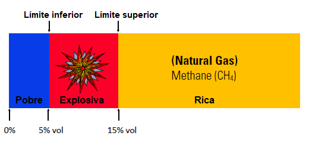

Los límites de inflamabilidad indican las proporciones de combustible y aire dentro de las cuales una mezcla puede arder.

Se expresan como un porcentaje de combustible presente en la mezcla.

Por ejemplo, si una mezcla contiene un 5 % de gas natural, significa que aproximadamente 5 de cada 100 moléculas de la mezcla son de gas natural y las otras 95 son aire.

Para el gas natural:

- Límite Inferior de Inflamabilidad (LII): 5 %
- Límite Superior de Inflamabilidad (LSI): 15 %

Esto significa que:

- Con menos del 5 % de gas, la mezcla es demasiado pobre en combustible para arder.
- Entre el 5 % y el 15 %, la mezcla puede inflamarse si existe una fuente de ignición.
- Con más del 15 %, la mezcla es demasiado rica en combustible y no dispone de suficiente oxígeno para mantener la combustión.

Por esta razón, no basta con que exista combustible y una chispa: también debe existir una proporción adecuada entre combustible y aire.

**Nota adicional:** Técnicamente, los límites de inflamabilidad se expresan como porcentaje en volumen de combustible en aire. Sin embargo, para gases, a la misma temperatura y presión, el porcentaje en volumen coincide con el porcentaje de moléculas (fracción molar). Por eso, a nivel introductorio, suele explicarse como: “5 de cada 100 moléculas son de combustible”

[Aquí](https://www.youtube.com/watch?v=Y3dcs_o__dQ) puedes ver más graficamente los límites de inflamabilidad.